# Base Pricing Analysis and Price Elasticity Estimation

Ben Heim, Marcell Milo-Sidlo, Pierre Chan, Julia Luo, Alicia Soosai

# Overview

The goal is to conduct a base pricing analysis. We estimate brand-level demand using scanner data, and then we make profitability predictions corresponding to specific base price changes. We estimate log-linear demand models that use (log) prices and promotions as inputs, and predict log quantities, `log(1+Q)`. The models predict the demand for a focal brand, and we control for (log) prices and promotions of three competitors. Obviously, this approach generalizes to an arbitrarily large number of competing products as long as the sample size is large enough.

Our focus is on the two top brands in the liquid laundry detergent category, *Tide* and *Gain*. Both are Procter & Gamble brands. The two closest competitors are *Arm & Hammer* and *Purex*.

# Packages

Make sure to install two packages that we have not used before: fixest and knitr.

```r
library(bit64)
library(data.table)
library(fixest)
library(knitr)
library(ggplot2)
```

# Data overview

The data are located in this folder:

```r
data_folder = "data"
```

The data source is an extract from the Nielsen RMS retail scanner data set. The data set captures weekly price and quantity data for all products (UPC’s) sold in the stores of a large number of U.S. retail chains. The Kilts data do not include all retailers (for example, Walmart is not part of the data), and the identity of the retailers is not revealed. However, we know if two stores belong to the same retail chain.

## Brand data

The data.table `brands` in `Brands.RData` includes brand information for the top five brands in three categories (product modules):

```
1036   FRUIT JUICE - LEMON/LIME
1040   FRUIT JUICE - ORANGE - OTHER CONTAINER
7012   DETERGENTS - HEAVY DUTY - LIQUID
```

The data include the brand code, brand description, and total revenue calculated across all observations. The top five brands were selected based on total brand revenue.

We will focus on the liquid laundry detergent category with corresponding `product_module_code` 7012.

## Store data

Inspect the table `stores` in the file `Stores.RData`. The variable `store_code_uc` identifies each retail stores. For some (but not all) stores we know the corresponding `retailer_code` that identifies the chain (banner) that the store belongs to. The data include the Scantrack (SMM) market code and the Scantrack market description. Scantrack markets correspond to large metropolitan market areas such as *Chicago* or *Raleigh-Durham* (see the data manual for a map of the Scantrack markets). The three-digit ZIP code of each store is also included.

## Movement data

The movement data (`move`) are in files of the form `brand_move_<module code>.RData`. The data are at the brand/store/week level and include prices and quantities (`units`). The data are aggregates of all UPC’s that share the same brand name. Brand prices are measured as the weighted average over all store/week UPC prices in equivalent units, and quantities represent total product volume measured in equivalent units such as ounces. In the liquid laundry detergent category (module 7012), prices represent dollars per ounce and units are total product volume in ounces per store/week. The aggregation weights are based on total store-level UPC revenue across all weeks, and hence the aggregation weights are constant within each store. The movement data also include a promotion indicator (`promo_dummy`), a logical `TRUE/FALSE` variable.

The `week_end` variable date is the last day of a Nielsen week, which always starts on a Sunday and ends on a Saturday. Note that prices may change during the period, and hence even the UPC-level price may be an average over more than one posted price. The sample includes data for the 2010-2013 period.

Please consult the official Kilts Center Retail Scanner Dataset Manual for all details.

# Prepare the data for the demand analysis

We first load the brand and store data.

```r
load(paste0(data_folder, "/Brands.RData"))
load(paste0(data_folder, "/Stores.RData"))
```

## Select the category and brands

*Choose the laundry detergent category (module) and select the corresponding brand-level meta data from the data table `brands`. Then sort (order) the brand data corresponding to total brand revenue, and select the **top four brands** (ranked by revenue).

```r
selected_module = 7012                 # Laundry detergent
laundry = brands[product_module_code == selected_module]
laundry_sorted = laundry[order(-revenue)][1:4]
laundry_sorted
```

| brand_code_uc | brand_descr | product_module_descr | product_module_code | revenue |
| --- | --- | --- | --- | --- |
| 653791 | TIDE - H-D LIQ | DETERGENTS - HEAVY DUTY - LIQUID | 7012 | 3659669291 |
| 557775 | GAIN - H-D LIQ | DETERGENTS - HEAVY DUTY - LIQUID | 7012 | 1201306647 |
| 507562 | ARM & HAMMER - H-D LIQ | DETERGENTS - HEAVY DUTY - LIQUID | 7012 | 1010503850 |
| 623280 | PUREX - H-D LIQ | DETERGENTS - HEAVY DUTY - LIQUID | 7012 | 495632613 |

*Let’s assign each brand a new name using a new variable, `brand_name`, and give the four brands simple names such as `Tide`, `Gain`, `ArmHammer`, and `Purex`. These simplified brand names will make our code and the estimation output more readable.* More specifically, create a new data containing the four selected brands and add to it the `brand_name` variable.

Note that we will add the brand names to the quantity, price, and promotion variables. In R, `price_ArmHammer` (as well as `price_Arm_Hammer`) are legal variable names, but `price_Arm&Hammer` and `price_Arm & Hammer` are not, and hence I do not suggest the brand names `Arm&Hammer` or `Arm & Hammer`.

```r
selected_brands = data.frame(
  product_id = c(653791, 557775, 507562, 623280),
  brand_name = c('Tide', 'Gain', 'ArmHammer', 'Purex')
)
print(selected_brands)
```

```
  product_id brand_name
1     653791       Tide
2     557775       Gain
3     507562  ArmHammer
4     623280      Purex
```

## Prepare the movement data

*Load the movement data, and—for better readability—change the variable names from `units` to `quantity` and from `promo_dummy` to `promotion` (you can use the `setnames` command for this). Change the data type of the `promotion` variable from `logical` to `numeric` using the `as.numeric` function. Finally, merge the new `brand_name` variable with the movement table (more precisely, perform an inner join, i.e. retain all observations that are present in both the parent and child data sets).

```r
load("data/brand_move_7012.RData")
library(data.table)
setnames(move, old = "promo_dummy", new = "promotion", skip_absent=TRUE)
setnames(move, old = "units", new = "quantity", skip_absent=TRUE)
setnames(move, old = "brand_code_uc", new = "product_id", skip_absent=TRUE)
move$promotion <- as.numeric(move$promotion)

move_with_brands <- merge(move, selected_brands, by = "product_id", all = FALSE)
head(move_with_brands)
```

| product_id | store_code_uc | week_end | price | quantity | promotion | brand_name |
| --- | --- | --- | --- | --- | --- | --- |
| 507562 | 1123 | 2010-01-02 | 0.06528157 | 2000 | 1 | ArmHammer |
| 507562 | 1123 | 2010-01-09 | 0.06852484 | 3300 | 1 | ArmHammer |
| 507562 | 1123 | 2010-01-16 | 0.07700768 | 1500 | 0 | ArmHammer |
| 507562 | 1123 | 2010-01-23 | 0.07757468 | 1275 | 0 | ArmHammer |
| 507562 | 1123 | 2010-01-30 | 0.06442845 | 4025 | 1 | ArmHammer |
| 507562 | 1123 | 2010-02-06 | 0.07757468 | 2275 | 0 | ArmHammer |

```r
final_data = merge(move, selected_brands, by = "product_id", all = FALSE)
print(final_data)
```

```
Key: <product_id>
         product_id store_code_uc   week_end      price quantity promotion
              <int>         <int>     <Date>      <num>    <num>     <num>
      1:     507562          1123 2010-01-02 0.06528157   2000.0         1
      2:     507562          1123 2010-01-09 0.06852484   3300.0         1
      3:     507562          1123 2010-01-16 0.07700768   1500.0         0
      4:     507562          1123 2010-01-23 0.07757468   1275.0         0
      5:     507562          1123 2010-01-30 0.06442845   4025.0         1
     ---
5256704:     653791       8386077 2013-11-30 0.17189507   1000.0         0
5256705:     653791       8386077 2013-12-07 0.13699283   6000.0         1
5256706:     653791       8386077 2013-12-14 0.17348442    650.0         0
5256707:     653791       8386077 2013-12-21 0.17500879    900.0         0
5256708:     653791       8386077 2013-12-28 0.16948965   1404.8         0
         brand_name
             <char>
      1:  ArmHammer
      2:  ArmHammer
      3:  ArmHammer
      4:  ArmHammer
      5:  ArmHammer
     ---
5256704:       Tide
5256705:       Tide
5256706:       Tide
5256707:       Tide
5256708:       Tide
```

## Remove outliers

Most data contain some “flaws” or outliers. Here is an easy way of removing such outliers:

First, we create a function that flags all observations in a vector `x`, for example a price series, as outliers if the ratio between a value and the median value among all `x` observations is below or above a threshold.

```r
isOutlier <- function(x, threshold_bottom, threshold_top) {
   is_outlier = rep(FALSE, times = length(x))
   median_x   = median(x, na.rm = TRUE)
   is_outlier[x/median_x < threshold_bottom | x/median_x > threshold_top] = TRUE
   return(is_outlier)
}
```

*Now run this function on the price data, separately for each brand and store. Then tabulate the number of outliers, and remove the corresponding observations from the data set.* I recommend to use a lower threshold (`threshold_bottom`) value of 0.35 and an upper threshold (`threshold_top`) of 2.5.

```r
threshold_bottom <- 0.35
threshold_top <- 2.5

final_data[, outlier_flag := isOutlier(price, threshold_bottom, threshold_top),
           by = .(store_code_uc, brand_name)]

sum(final_data$outlier_flag)
```

```
[1] 17268
```

```r
final_data = final_data[outlier_flag == FALSE]

# removing flag
final_data[, outlier_flag := NULL]

final_data
```

| product_id | store_code_uc | week_end | price | quantity | promotion | brand_name |
| --- | --- | --- | --- | --- | --- | --- |
| 507562 | 1123 | 2010-01-02 | 0.06528157 | 2000.00 | 1 | ArmHammer |
| 507562 | 1123 | 2010-01-09 | 0.06852484 | 3300.00 | 1 | ArmHammer |
| 507562 | 1123 | 2010-01-16 | 0.07700768 | 1500.00 | 0 | ArmHammer |
| 507562 | 1123 | 2010-01-23 | 0.07757468 | 1275.00 | 0 | ArmHammer |
| 507562 | 1123 | 2010-01-30 | 0.06442845 | 4025.00 | 1 | ArmHammer |
| 507562 | 1123 | 2010-02-06 | 0.07757468 | 2275.00 | 0 | ArmHammer |
| 507562 | 1123 | 2010-02-13 | 0.07757468 | 1600.00 | 0 | ArmHammer |
| 507562 | 1123 | 2010-02-20 | 0.06253663 | 4525.00 | 1 | ArmHammer |
| 507562 | 1123 | 2010-02-27 | 0.07757468 | 2200.00 | 0 | ArmHammer |
| 507562 | 1123 | 2010-03-06 | 0.07757468 | 1550.00 | 0 | ArmHammer |

[output cut: 9990 more lines]

## Reshape the movement data from long to wide format

To prepare the data for the regression analysis, we need to **reshape the data from long to wide format** using **`dcast`**.

All the details on casting and the reverse operation (melting from wide to long format using `melt`) are explained in the data.table html vignettes:

https://rdatatable.gitlab.io/data.table/articles/datatable-reshape.html

Let’s be specific about the structure of the data that we need to use to estimate a demand model. We would like to obtain a table with observations, characterized by a combination of store id (`store_code_uc`) and week (`week_end`) in rows, and information on quantities, prices, and promotions in columns. Quantities, prices, and promotions are brand-specific.

```r
final_data = final_data[, .(store_code_uc, week_end, brand_name, quantity, price, promotion)]

final_data <- dcast(
  final_data,
  store_code_uc + week_end ~ brand_name,
  value.var = c("quantity", "price", "promotion")
)
```

## Merge store information with the movement data

*Now merge the movement data with the store meta data, in particular with the retailer code, the Scantrack (SMM) market code, and the Scantrack market description. But only with the store meta data where we have a valid retailer code. Hence, we need to remove store data if the retailer code is missing (`NA`). Use the `is.na` function to check if `retailer_code` is `NA` or not.*

```r
load("data/Stores.RData")
ls()
```

```
 [1] "brands"           "data_folder"      "final_data"       "isOutlier"
 [5] "laundry"          "laundry_sorted"   "move"             "move_with_brands"
 [9] "selected_brands"  "selected_module"  "stores"           "threshold_bottom"
[13] "threshold_top"
```

```r
print(stores)
```

```
Key: <store_code_uc>
       store_code_uc retailer_code store_zip3 SMM_code  SMM_description
               <int>         <int>      <int>    <int>           <char>
    1:          1123            89        441       16        Cleveland
    2:          1852            89        165       16        Cleveland
    3:          2324            NA        606        2          Chicago
    4:          4809            98        100        9         Urban NY
    5:          4954            NA        100        9         Urban NY
   ---
17063:       8385693            NA        606        2          Chicago
17064:       8386077          4904        113        9         Urban NY
17065:       8387558           128        851       38          Phoenix
17066:       8388006            NA        279       49         Richmond
17067:       8388364            NA        274       39 Raleigh - Durham
```

```r
valid_store_meta <- stores[!is.na(stores$retailer_code)]
final_data_with_store <- merge(final_data, valid_store_meta, by = "store_code_uc", all = FALSE)
head(final_data_with_store)
```

| store_code_uc | week_end | quantity_ArmHammer | quantity_Gain | quantity_Purex | quantity_Tide | price_ArmHammer | price_Gain | price_Purex | price_Tide | promotion_ArmHammer | promotion_Gain | promotion_Purex | promotion_Tide | retailer_code | store_zip3 | SMM_code | SMM_description |
| --- | --- | --- | --- | --- | --- | --- | --- | --- | --- | --- | --- | --- | --- | --- | --- | --- | --- |
| 1123 | 2010-01-02 | 2000 | 400 | 1060 | 3000 | 0.06528157 | 0.1209109 | 0.08248828 | NaN | 1 | 0 | 0 | NA | 89 | 441 | 16 | Cleveland |
| 1123 | 2010-01-09 | 3300 | 700 | 1582 | 9600 | 0.06852484 | 0.1209109 | 0.08248828 | 0.1299496 | 1 | 0 | 0 | 1 | 89 | 441 | 16 | Cleveland |
| 1123 | 2010-01-16 | 1500 | 600 | 4988 | 3450 | 0.07700768 | 0.1209109 | 0.06126852 | 0.1519637 | 0 | 0 | 1 | 0 | 89 | 441 | 16 | Cleveland |
| 1123 | 2010-01-23 | 1275 | 1300 | 832 | 2700 | 0.07757468 | 0.1015777 | 0.08214914 | 0.1524072 | 0 | 1 | 0 | 0 | 89 | 441 | 16 | Cleveland |
| 1123 | 2010-01-30 | 4025 | 300 | 1142 | 2100 | 0.06442845 | 0.1209109 | 0.08214914 | 0.1524981 | 1 | 0 | 0 | 0 | 89 | 441 | 16 | Cleveland |
| 1123 | 2010-02-06 | 2275 | 300 | 1786 | 3300 | 0.07757468 | 0.1209109 | 0.08214914 | 0.1519637 | 0 | 0 | 0 | 0 | 89 | 441 | 16 | Cleveland |

## Create time variables or trends

*A time trend records the progress of time. For example, a time trend at the week-level may equal 1 in the first week in the data, 2 in the second week, etc., whereas a trend at the month-level may equal 1 in the first month, 2 in the second month, etc.*

*I suggest you create a monthly time trend. Use the functions `year` and `month` to extract the year and month components of the week (`week_end`) variable in the movement data (alternatively, you could use the `week` function if you wanted to create a time trend at the week-level). Then, use the following code to create the monthly trend:*

```r
library(lubridate)
final_data_with_store$week_end <- as.Date(final_data_with_store$week_end)
final_data_with_store[, year := year(week_end)]
final_data_with_store[, month := month(week_end)]
final_data_with_store[, month_trend := 12*(year - min(year)) + month]
head(final_data_with_store[, .(week_end, year, month, month_trend)])
```

| week_end | year | month | month_trend |
| --- | --- | --- | --- |
| 2010-01-02 | 2010 | 1 | 1 |
| 2010-01-09 | 2010 | 1 | 1 |
| 2010-01-16 | 2010 | 1 | 1 |
| 2010-01-23 | 2010 | 1 | 1 |
| 2010-01-30 | 2010 | 1 | 1 |
| 2010-02-06 | 2010 | 2 | 2 |

## Remove missing values

Finally, *retain only complete cases*, i.e. rows without missing values:

```r
final_data_with_store = final_data_with_store[complete.cases(final_data_with_store)]
print(final_data_with_store)
```

```
Key: <store_code_uc>
         store_code_uc   week_end quantity_ArmHammer quantity_Gain
                 <int>     <Date>              <num>         <num>
      1:          1123 2010-01-09               3300           700
      2:          1123 2010-01-16               1500           600
      3:          1123 2010-01-23               1275          1300
      4:          1123 2010-01-30               4025           300
      5:          1123 2010-02-06               2275           300
     ---
1259348:       8386077 2013-11-30                730           450
1259349:       8386077 2013-12-07                245           200
1259350:       8386077 2013-12-14                100           750
1259351:       8386077 2013-12-21               2535           100
1259352:       8386077 2013-12-28                240             0
         quantity_Purex quantity_Tide price_ArmHammer price_Gain price_Purex
```

[output cut: 51 more lines]

# Data inspection

## Observations and geographic coverage

*First, document the number of observations and the number of unique stores in the data.*

*Second, we assesss if the included stores have broad geographic coverage. We hence create a summary table that records the number of observations for each separate Scantrack market:*

```r
market_coverage = final_data_with_store[, .(n_obs = .N), by = SMM_description]
```

Note the use of the data.table internal `.N`: `.N` is the number of observations, either in the whole data table, or—as in this case—the number of observations within each group defined by the `by =` statement.

A convenient way to print a table is provided by the **`kable`** function that is included in the `knitr` package. Please consult the documentation for `kable` to see all options. Particularly useful are the options `col.names`, which is used below, and `digits`, which allows you to set the number of digits to the right of the decimal point.

*Now use `kable` to document the number of observations within each Scantrack market.*

```r
kable(market_coverage, col.names = c("Scantrack market", "No. obs."))
```

| Scantrack market | No. obs. |
| --- | --- |
| Cleveland | 24891 |
| Chicago | 88257 |
| Boston | 42219 |
| New Orleans - Mobile | 27704 |
| Urban NY | 23363 |
| Suburban NY | 39284 |
| Albany | 8918 |
| San Francisco | 40263 |
| Rem Omaha | 6672 |
| Nashville | 5880 |
| Rem Los Angeles - Collar | 19850 |
| Exurban NY | 12285 |
| Salt Lake City | 23812 |
| Atlanta | 10049 |
| Miami | 56504 |
| Jacksonville | 16962 |
| Oklahoma City - Tulsa | 6654 |
| Sacramento | 14089 |
| Rem Jacksonville | 14786 |
| Kansas City | 7979 |
| Memphis | 5388 |
| Richmond | 8701 |
| Phoenix | 29709 |
| Los Angeles | 127244 |
| Rem Atlanta | 9014 |
| Rem Richmond - Norfolk | 2061 |
| Washington DC | 8636 |
| Rem Seattle - Portland | 9465 |
| West Texas | 8798 |
| Las Vegas | 19845 |
| San Antonio | 16650 |
| Minneapolis | 18830 |
| Detroit | 13109 |
| Rem Boston | 24688 |
| Louisville | 7487 |
| St. Louis | 17079 |
| Rem Milwaukee | 11217 |
| Omaha | 6903 |
| Milwaukee | 15987 |
| Tampa | 41020 |
| Rem St. Louis | 7633 |
| Raleigh - Durham | 7478 |
| Charlotte | 4166 |
| Seattle | 25835 |
| Rem Indianapolis | 5664 |
| Pittsburgh | 20966 |
| Rem Charlotte | 6884 |
| San Diego | 22955 |
| Birmingham | 11440 |
| Orlando | 29707 |
| Portland OR | 17985 |
| Dallas | 21053 |
| Rem Denver | 13596 |
| Philadelphia | 14982 |
| Houston | 22434 |
| Baltimore | 6533 |
| Cincinnati | 7528 |
| Des Moines | 5260 |
| Rem Philadelphia | 1235 |
| Buffalo - Rochester | 4172 |
| Denver | 15460 |
| Rem New Orleans - Mobile | 7358 |
| Rem West Texas | 18370 |
| Grand Rapids | 5605 |
| Hartford - New Haven | 11056 |
| Columbus | 6064 |
| Rem Pittsburgh | 2151 |
| Indianapolis | 6331 |
| Rem North California | 13171 |
| Rem Kansas City | 8380 |
| Rem Minneapolis | 3995 |
| Rem Detroit | 1771 |
| Rem Greenville | 2274 |
| Little Rock | 2838 |
| Rem Memphis - Little Rock | 2487 |
| Syracuse | 2283 |

## Price variation

Before estimating the demand models we would like to understand the degree of price variation in the data. Comment on why this is important for a regression analysis such as demand estimation!

We will predict demand for Tide and Gain. For each of these two brands separately, we would like to visualize the overall degree of price variation across observations, and also the variation in relative prices with respect to the competing brands.

- *To visualize the (own) price variation, normalize the prices of Tide and Gain by dividing by the average of these prices, and show the histogram of normalized prices.*

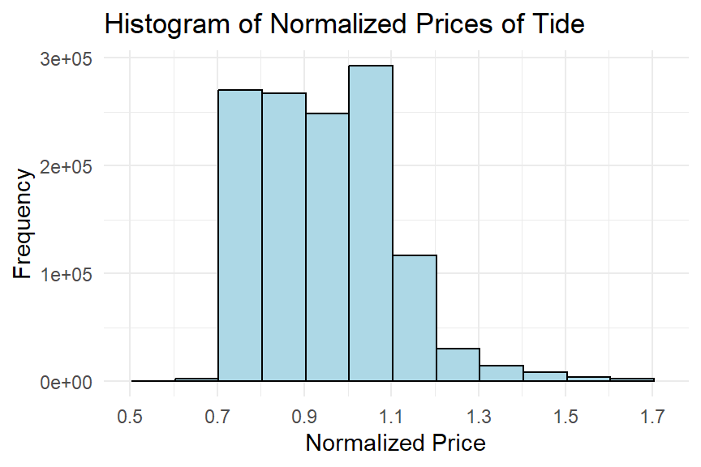

```r
tide_average = final_data_with_store[, mean(price_Tide, na.rm = TRUE)]
norm_tide = final_data_with_store[, price_Tide / tide_average]

df_tide = data.frame(norm_tide)

x_limits = quantile(df_tide$norm_tide, probs = c(0.00, 0.997), na.rm = TRUE)

ggplot(df_tide, aes(x = norm_tide)) +
  geom_histogram(binwidth = 0.1, fill = "lightblue", color = "black") +
  scale_x_continuous(breaks = seq(min(df_tide$norm_tide), max(df_tide$norm_tide), by = 0.2),
                     labels = scales::number_format(accuracy = 0.1),
                     limits = x_limits) +
  labs(title = "Histogram of Normalized Prices of Tide",
       x = "Normalized Price",
       y = "Frequency") +
  theme_minimal()
```

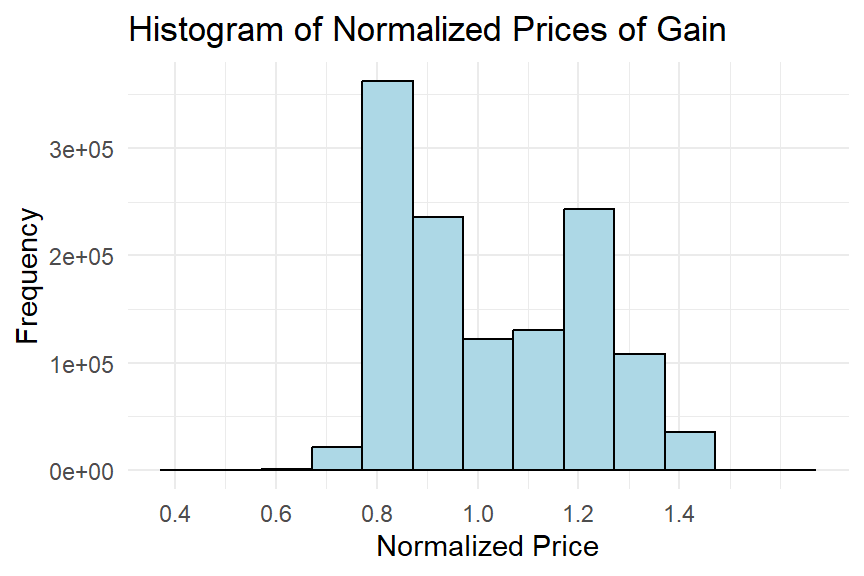

```r
gain_average = final_data_with_store[, mean(price_Gain, na.rm = TRUE)]
norm_gain = final_data_with_store[, price_Gain / gain_average]

df_gain = data.frame(norm_gain)

ggplot(df_gain, aes(x = norm_gain)) +
  geom_histogram(binwidth = 0.1, fill = "lightblue", color = "black") +
  scale_x_continuous(breaks = seq(min(df_gain$norm_gain, na.rm = TRUE), max(df_gain$norm_gain, na.rm = TRUE), by = 0.2),
                     labels = scales::number_format(accuracy = 0.1)) +
  labs(title = "Histogram of Normalized Prices of Gain",
       x = "Normalized Price",
       y = "Frequency") +
  theme_minimal()
```

- *To visualize relative prices, calculate the ratio of Tide and Gain prices with respect to the three competing brands, and show the histogram of relative prices.*

Note: To avoid that the scale of a graph is distorted by a few outliers, use the `limits` option in `scale_x_continuous` (see the ggplot2 introduction). This also helps to make the graphs comparable with each other.

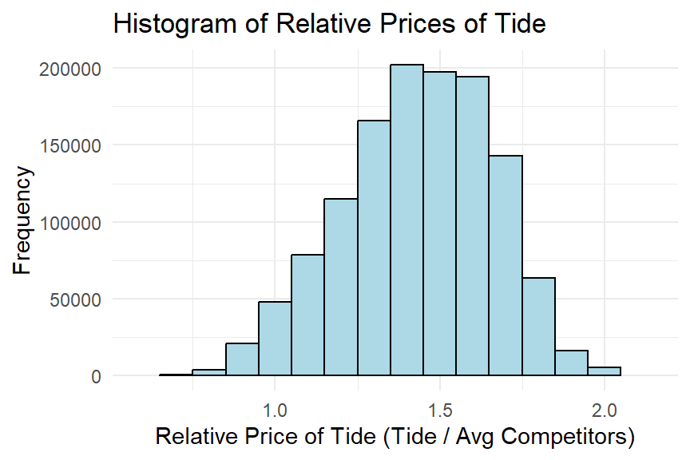

```r
df_tide = final_data_with_store[, .(
  norm_tide = price_Tide / ((price_ArmHammer + price_Purex + price_Gain) / 3)
), by = week_end]

x_limits = quantile(df_tide$norm_tide, probs = c(0.00, 0.997), na.rm = TRUE)

ggplot(df_tide, aes(x = norm_tide)) +
  geom_histogram(binwidth = 0.1, fill = "lightblue", color = "black") +
  scale_x_continuous(limits = x_limits) +
  labs(title = "Histogram of Relative Prices of Tide",
       x = "Relative Price of Tide (Tide / Avg Competitors)",
       y = "Frequency") +
  theme_minimal()
```

[figure not shown]

```r
df_gain = final_data_with_store[, .(
  norm_ggin = price_Gain / ((price_ArmHammer + price_Purex + price_Tide) / 3)
), by = week_end]

ggplot(df_gain, aes(x = norm_gain)) +
  geom_histogram(binwidth = 0.1, fill = "lightblue", color = "black") +
  labs(title = "Histogram of Relative Prices of Gain",
       x = "Relative Price of Gain (Gain / Avg Competitors)",
       y = "Frequency") +
  theme_minimal()
```

## Summary of data inspection

*Discuss the data description, including sample size, geographic coverage, and the results on own and relative price variation.*.

From having visualized the provided data, we are able to determine that the largest single market in terms of number of observations, is Los Angeles, with 127 244 unique instances. This is followed by Chicago and Miami, with 88 257 and 56 504 observations respectively.

In terms of own price variation over time, we can see two very different graphs for Tide and Gain products. The graph of the normalized price variation of Tide tells us that for the majority of the time, the price of the product is (mostly) evenly distributed between 70% and 110% of the average price, with most instances of the product being priced between 100-110% of the average price. This stands in contrast to Gain products, who display a bimodal distribution, with the majority of prices being between 75%-95%, and 115%-125% of the average price. The most common price was around 80% of the average price.

# Estimation

Now we are ready to estimate demand models for Tide and Gain.

We want to estimate a sequence of models with an increasing number of controls and compare the stability of the key results across these models. In all models the output is `log(1+quantity_<brand name>)`.

To keep things simple, we will initially estimate demand for Tide only.

Let’s start with the following models:

1. log of own price as only input
2. Add store fixed effects
3. Add a time trend—maybe linear, or a polynomial with higher-order terms
4. Instead of a time trend add fixed effects for each month (more precisely: for each year/month combination)

*Estimate the models using the `feols` function from the fixest package (consult the corresponding fixest guide included among the R learning resources on Canvas). Store the regression outputs in some appropriately named variables (objects).*

```r
head(final_data_with_store)
```

| store_code_uc | week_end | quantity_ArmHammer | quantity_Gain | quantity_Purex | quantity_Tide | price_ArmHammer | price_Gain | price_Purex | price_Tide | promotion_ArmHammer | promotion_Gain | promotion_Purex | promotion_Tide | retailer_code | store_zip3 | SMM_code | SMM_description | year | month | month_trend |
| --- | --- | --- | --- | --- | --- | --- | --- | --- | --- | --- | --- | --- | --- | --- | --- | --- | --- | --- | --- | --- |
| 1123 | 2010-01-09 | 3300 | 700 | 1582 | 9600 | 0.06852484 | 0.1209109 | 0.08248828 | 0.1299496 | 1 | 0 | 0 | 1 | 89 | 441 | 16 | Cleveland | 2010 | 1 | 1 |
| 1123 | 2010-01-16 | 1500 | 600 | 4988 | 3450 | 0.07700768 | 0.1209109 | 0.06126852 | 0.1519637 | 0 | 0 | 1 | 0 | 89 | 441 | 16 | Cleveland | 2010 | 1 | 1 |
| 1123 | 2010-01-23 | 1275 | 1300 | 832 | 2700 | 0.07757468 | 0.1015777 | 0.08214914 | 0.1524072 | 0 | 1 | 0 | 0 | 89 | 441 | 16 | Cleveland | 2010 | 1 | 1 |
| 1123 | 2010-01-30 | 4025 | 300 | 1142 | 2100 | 0.06442845 | 0.1209109 | 0.08214914 | 0.1524981 | 1 | 0 | 0 | 0 | 89 | 441 | 16 | Cleveland | 2010 | 1 | 1 |
| 1123 | 2010-02-06 | 2275 | 300 | 1786 | 3300 | 0.07757468 | 0.1209109 | 0.08214914 | 0.1519637 | 0 | 0 | 0 | 0 | 89 | 441 | 16 | Cleveland | 2010 | 2 | 2 |
| 1123 | 2010-02-13 | 1600 | 0 | 1288 | 6100 | 0.07757468 | 0.1209109 | 0.08214914 | 0.1303309 | 0 | 0 | 0 | 1 | 89 | 441 | 16 | Cleveland | 2010 | 2 | 2 |

```r
fit_base <- feols(
  log(1 + quantity_Tide) ~ log(price_Tide),
  data = final_data_with_store
)

fit_store_FE <- feols(
  log(1 + quantity_Tide) ~ log(price_Tide) | store_code_uc,
  data = final_data_with_store
)

fit_trend <- feols(
  log(1 + quantity_Tide) ~ log(price_Tide) + month | store_code_uc,
  data = final_data_with_store
)

fit_month_FE <- feols(
  log(1 + quantity_Tide) ~ log(price_Tide) | store_code_uc + year + month,
  data = final_data_with_store
)

fit_promo_Tide <- feols(
  log(1 + quantity_Tide) ~ log(price_Tide) +
    promotion_Tide | store_code_uc + year + month,
  data = final_data_with_store
)

etable(fit_base, fit_store_FE, fit_trend, fit_month_FE, fit_promo_Tide)
```

|  |  | fit_base | fit_store_FE | fit_trend | fit_month_FE | fit_promo_Tide |
| --- | --- | --- | --- | --- | --- | --- |
| 1 | Dependent Var.: | log(1+quantity_Tide) | log(1+quantity_Tide) | log(1+quantity_Tide) | log(1+quantity_Tide) | log(1+quantity_Tide) |
| 2 |  |  |  |  |  |  |
| 3 | Constant | -6.374*** (0.0127) |  |  |  |  |
| 4 | log(price_Tide) | -7.465*** (0.0067) | -5.612*** (0.0440) | -5.607*** (0.0440) | -5.647*** (0.0440) | -4.076*** (0.0541) |
| 5 | month |  |  | -0.0101*** (0.0002) |  |  |
| 6 | promotion_Tide |  |  |  |  | 0.3665*** (0.0078) |
| 7 | Fixed-Effects: | -------------------- | -------------------- | -------------------- | -------------------- | -------------------- |
| 8 | store_code_uc | No | Yes | Yes | Yes | Yes |
| 9 | year | No | No | No | Yes | Yes |
| 10 | month | No | No | No | Yes | Yes |

[output cut: 5 more lines]

**Hint**: Recall that it is perfectly legitimate in R to write model formulas such as

```
log(1+quantity_<brand name>) ~ log(price_<brand name>)
```

Hence, there is no need to create new variables such as the logarithm of own price, etc., before estimating a demand model.

You can display the regression coefficients using the `summary` function. As a much more elegant solution, however, I recommend using the `etable` function in the `fixest` package, which produces nicely formatted output.

Please **consult the fixest guide on how to use `etable`**, and **go through the** *Checklist for creating LaTeX tables using `etable`*!

Here is an example (note that the `fit` objects are the regression outputs—adjust the names if necessary):

```r
#etable(fit_base, fit_store_FE, fit_trend, fit_month_FE,
       #tex = TRUE,
       #fitstat = c("n", "r2"), signif.code = NA,
       #cluster = c("store_code_uc", "month_trend"))
```

Note the option `cluster = c("store_code_uc", "month_trend")`, which tells `etable` to show standard errors that are clustered at the store and month level. These clustered standard errors will be larger and more accurate than regular standard errors because they reflect that the error terms in the regression are likely correlated at the store and month level.

Before moving on, you may want to remove the regression output objects that are no longer used, because they take up much space in memory:

```r
rm(fit_base, fit_store_FE, fit_trend)
```

## Controlling for competitor prices

*Now add the competitor prices to the demand model.*

```r
library(fixest)

fit_base_competitor <- feols(
  log(1 + quantity_Tide) ~ log(price_Tide) + log(price_Gain),
  data = final_data_with_store
)

fit_store_FE_competitor <- feols(
  log(1 + quantity_Tide) ~ log(price_Tide) + log(price_Gain) +
    log(price_ArmHammer) + log(price_Purex) | store_code_uc,
  data = final_data_with_store
)

fit_trend_competitor <- feols(
  log(1 + quantity_Tide) ~ log(price_Tide) + log(price_Gain) +
    log(price_ArmHammer) + log(price_Purex) + month | store_code_uc,
  data = final_data_with_store
)

fit_month_FE_competitor <- feols(
  log(1 + quantity_Tide) ~ log(price_Tide) + log(price_Gain) +
    log(price_ArmHammer) + log(price_Purex) | store_code_uc + year + month,
  data = final_data_with_store)

etable(fit_base_competitor, fit_store_FE_competitor, fit_trend_competitor,
       fit_month_FE_competitor)
```

|  |  | fit_base_competitor | fit_store_FE_compe.. | fit_trend_competitor | fit_month_FE_compe.. |
| --- | --- | --- | --- | --- | --- |
| 1 | Dependent Var.: | log(1+quantity_Tide) | log(1+quantity_Tide) | log(1+quantity_Tide) | log(1+quantity_Tide) |
| 2 |  |  |  |  |  |
| 3 | Constant | -7.559*** (0.0128) |  |  |  |
| 4 | log(price_Tide) | -5.792*** (0.0084) | -5.639*** (0.0436) | -5.636*** (0.0435) | -5.643*** (0.0430) |
| 5 | log(price_Gain) | -2.126*** (0.0068) | 0.7171*** (0.0180) | 0.7075*** (0.0181) | 0.6279*** (0.0188) |
| 6 | log(price_ArmHammer) |  | 0.1360*** (0.0052) | 0.1229*** (0.0051) | 0.1048*** (0.0050) |
| 7 | log(price_Purex) |  | -0.0544*** (0.0054) | -0.0495*** (0.0054) | 0.1565*** (0.0075) |
| 8 | month |  |  | -0.0083*** (0.0002) |  |
| 9 | Fixed-Effects: | -------------------- | -------------------- | -------------------- | -------------------- |
| 10 | store_code_uc | No | Yes | Yes | Yes |

[output cut: 7 more lines]

## Controlling for promotions

*Now add the promotions dummies, first just for Tide, then for all brands. Compare the results. Did controlling for promotions change the own price elasticity estimate in an expected manner?*

```r
#Tide

fit_base_competitor_promo <- feols(
  log(1 + quantity_Tide) ~ log(price_Tide) + log(price_Gain) +
    log(price_ArmHammer) + log(price_Purex) + promotion_Tide,
  data = final_data_with_store
)

fit_store_FE_competitor_promo <- feols(
  log(1 + quantity_Tide) ~ log(price_Tide) + log(price_Gain) +
    log(price_ArmHammer) + log(price_Purex) + promotion_Tide | store_code_uc,
  data = final_data_with_store
)

fit_trend_competitor_promo <- feols(
  log(1 + quantity_Tide) ~ log(price_Tide) + log(price_Gain) +
    log(price_ArmHammer) + log(price_Purex) + month +
    promotion_Tide | store_code_uc,
  data = final_data_with_store
)

fit_month_FE_competitor_promo <- feols(
  log(1 + quantity_Tide) ~ log(price_Tide) + log(price_Gain) +
    log(price_ArmHammer) + log(price_Purex) +
    promotion_Tide | store_code_uc + year + month,
  data = final_data_with_store
)

etable(fit_base_competitor_promo, fit_store_FE_competitor_promo,
       fit_trend_competitor_promo, fit_month_FE_competitor_promo)
```

|  |  | fit_base_competito.. | fit_store_FE_compe.. | fit_trend_competit.. | fit_month_FE_compe.. |
| --- | --- | --- | --- | --- | --- |
| 1 | Dependent Var.: | log(1+quantity_Tide) | log(1+quantity_Tide) | log(1+quantity_Tide) | log(1+quantity_Tide) |
| 2 |  |  |  |  |  |
| 3 | Constant | -7.072*** (0.0129) |  |  |  |
| 4 | log(price_Tide) | -4.127*** (0.0096) | -3.971*** (0.0527) | -3.985*** (0.0528) | -4.180*** (0.0548) |
| 5 | log(price_Gain) | -1.770*** (0.0075) | 0.5498*** (0.0177) | 0.5448*** (0.0178) | 0.4990*** (0.0185) |
| 6 | log(price_ArmHammer) | -1.111*** (0.0039) | 0.0931*** (0.0051) | 0.0843*** (0.0051) | 0.0753*** (0.0049) |
| 7 | log(price_Purex) | -0.2270*** (0.0029) | -0.0422*** (0.0048) | -0.0389*** (0.0048) | 0.1315*** (0.0071) |
| 8 | promotion_Tide | 0.4755*** (0.0023) | 0.3907*** (0.0080) | 0.3869*** (0.0080) | 0.3416*** (0.0077) |
| 9 | month |  |  | -0.0058*** (0.0002) |  |
| 10 | Fixed-Effects: | -------------------- | -------------------- | -------------------- | -------------------- |

[output cut: 8 more lines]

```r
# All Brands

fit_base_competitor_promo2 <- feols(
  log(1 + quantity_Tide) ~ log(price_Tide) + log(price_Gain) +
    log(price_ArmHammer) + log(price_Purex) + promotion_Tide +
    promotion_Gain + promotion_ArmHammer + promotion_Purex,
  data = final_data_with_store
)

fit_store_FE_competitor_promo2 <- feols(
  log(1 + quantity_Tide) ~ log(price_Tide) + log(price_Gain) +
    log(price_ArmHammer) + log(price_Purex) + promotion_Tide +
    promotion_Gain + promotion_ArmHammer + promotion_Purex | store_code_uc,
  data = final_data_with_store
)

fit_trend_competitor_promo2 <- feols(
  log(1 + quantity_Tide) ~ log(price_Tide) + log(price_Gain) +
    log(price_ArmHammer) + log(price_Purex) + month +
    promotion_Tide + promotion_Gain + promotion_ArmHammer + promotion_Purex |
    store_code_uc, data = final_data_with_store
)

fit_month_FE_competitor_promo2 <- feols(
  log(1 + quantity_Tide) ~ log(price_Tide) + log(price_Gain) +
    log(price_ArmHammer) + log(price_Purex) + promotion_Tide +
    promotion_Gain + promotion_ArmHammer + promotion_Purex | store_code_uc +
    year + month, data = final_data_with_store
)

etable(fit_base_competitor_promo2, fit_store_FE_competitor_promo2,
       fit_trend_competitor_promo2, fit_month_FE_competitor_promo2)
```

|  |  | fit_base_competit..2 | fit_store_FE_comp..2 | fit_trend_competi..2 | fit_month_FE_comp..2 |
| --- | --- | --- | --- | --- | --- |
| 1 | Dependent Var.: | log(1+quantity_Tide) | log(1+quantity_Tide) | log(1+quantity_Tide) | log(1+quantity_Tide) |
| 2 |  |  |  |  |  |
| 3 | Constant | -6.583*** (0.0131) |  |  |  |
| 4 | log(price_Tide) | -3.307*** (0.0100) | -4.003*** (0.0531) | -4.015*** (0.0532) | -4.196*** (0.0549) |
| 5 | log(price_Gain) | -2.273*** (0.0090) | 0.6922*** (0.0238) | 0.6830*** (0.0238) | 0.5748*** (0.0242) |
| 6 | log(price_ArmHammer) | -1.210*** (0.0049) | 0.1437*** (0.0092) | 0.1325*** (0.0092) | 0.1223*** (0.0087) |
| 7 | log(price_Purex) | -0.2223*** (0.0031) | -0.0661*** (0.0060) | -0.0624*** (0.0060) | 0.1515*** (0.0129) |
| 8 | promotion_Tide | 0.5647*** (0.0023) | 0.3832*** (0.0082) | 0.3799*** (0.0082) | 0.3411*** (0.0077) |
| 9 | promotion_Gain | -0.4755*** (0.0029) | 0.0577*** (0.0060) | 0.0559*** (0.0060) | 0.0314*** (0.0053) |
| 10 | promotion_ArmHammer | -0.2909*** (0.0024) | 0.0331*** (0.0062) | 0.0311*** (0.0062) | 0.0346*** (0.0059) |

[output cut: 11 more lines]

With the exception of the fit_base model, all other models are generally the same compared to the models with the single promotion.

*Summarize and comment on the estimation results. Was it necessary to control for store fixed effects, time trends/fixed effects, as well as competitor prices and promotions? What do we learn from the magnitudes of the own and cross-price elasticities?*

In the base model, Tide’s own-price elasticity is quite large, with a coefficient of -7.47, indicating that a 1% increase in Tide’s price would result in a 7.47% decrease in demand. However, after including store fixed effects, the magnitude of this elasticity decreases to -5.61, suggesting that the initial model without controls overestimated Tide’s price sensitivity by failing to account for unobserved differences across stores. The R-squared value also jumps from 0.496 in the base model to 0.846, which demonstrates the significant improvement in model fit when store-specific factors are considered.

Time trends and month fixed effects did not have much of an impact on the overall results. After introducing a month trend, the price elasticity remains at -5.61, and the inclusion of fixed effects for each year and month leads to a slight decrease in price elasticity to -5.65. The R-squared improves marginally to 0.851, indicating that time trends capture some of the seasonality in Tide’s demand, but store fixed effects remain the most important control.

Lastly, the introduction of Tide’s promotional activities further improves the model’s explanatory power, with the R-squared rising to 0.857. The own-price elasticity decreases further to -4.08, indicating that promotions significantly mitigate the negative impact of price increases. Promotions for Tide have a strong and positive effect on sales, increasing demand by approximately 36.65%. This confirms that promotions are a major driver of Tide’s demand and should be accounted for when estimating price sensitivity.

We will use the final model including all variables (I called it `fit_promo_comp`) as our preferred model. To make this final model distinguishable from the regression output for Gain we rename it:

```r
fit_promo_comp <- feols(
  log(1 + quantity_Tide) ~ log(price_Tide) + log(price_Gain) + log(price_Purex)
  + log(price_ArmHammer) + promotion_Tide + promotion_Gain + promotion_ArmHammer
  + promotion_Purex | store_code_uc + year + month, data = final_data_with_store
)
```

```r
fit_Tide = fit_promo_comp
```

## Demand model for Gain

*Now repeat the steps to estimate demand for Gain.*

```r
fit_base <- feols(
  log(1 + quantity_Gain) ~ log(price_Gain),
  data = final_data_with_store
)

fit_store_FE <- feols(
  log(1 + quantity_Gain) ~ log(price_Gain) | store_code_uc,
  data = final_data_with_store
)

fit_trend <- feols(
  log(1 + quantity_Gain) ~ log(price_Gain) + month | store_code_uc,
  data = final_data_with_store
)

fit_month_FE <- feols(
  log(1 + quantity_Gain) ~ log(price_Gain) | store_code_uc + year + month,
  data = final_data_with_store
)

fit_promo_Gain <- feols(
  log(1 + quantity_Gain) ~ log(price_Gain) + promotion_Gain | store_code_uc +
    year + month,
  data = final_data_with_store
)

etable(fit_base, fit_store_FE, fit_trend, fit_month_FE, fit_promo_Gain)
```

|  |  | fit_base | fit_store_FE | fit_trend | fit_month_FE | fit_promo_Gain |
| --- | --- | --- | --- | --- | --- | --- |
| 1 | Dependent Var.: | log(1+quantity_Gain) | log(1+quantity_Gain) | log(1+quantity_Gain) | log(1+quantity_Gain) | log(1+quantity_Gain) |
| 2 |  |  |  |  |  |  |
| 3 | Constant | -14.55*** (0.0160) |  |  |  |  |
| 4 | log(price_Gain) | -9.967*** (0.0078) | -6.709*** (0.0326) | -6.690*** (0.0326) | -6.626*** (0.0328) | -4.779*** (0.0417) |
| 5 | month |  |  | 0.0157*** (0.0005) |  |  |
| 6 | promotion_Gain |  |  |  |  | 0.7303*** (0.0121) |
| 7 | Fixed-Effects: | -------------------- | -------------------- | -------------------- | -------------------- | -------------------- |
| 8 | store_code_uc | No | Yes | Yes | Yes | Yes |
| 9 | year | No | No | No | Yes | Yes |
| 10 | month | No | No | No | Yes | Yes |

[output cut: 5 more lines]

```r
library(fixest)

fit_base_competitor <- feols(
  log(1 + quantity_Gain) ~ log(price_Tide) + log(price_Gain),
  data = final_data_with_store
)

fit_store_FE_competitor <- feols(
  log(1 + quantity_Gain) ~ log(price_Gain) + log(price_Tide) + log(price_Purex)
  + log(price_ArmHammer) | store_code_uc,
  data = final_data_with_store
)

fit_trend_competitor <- feols(
  log(1 + quantity_Gain) ~ log(price_Gain) + log(price_Tide) + log(price_Purex)
  + log(price_ArmHammer) + month | store_code_uc,
  data = final_data_with_store
)

fit_month_FE_competitor <- feols(
  log(1 + quantity_Gain) ~ log(price_Gain) + log(price_Tide) + log(price_Purex)
  + log(price_ArmHammer) + log(price_Purex) +
    log(price_ArmHammer) | store_code_uc + year + month,
  data = final_data_with_store
)

etable(fit_base_competitor, fit_store_FE_competitor, fit_trend_competitor,
       fit_month_FE_competitor)
```

|  |  | fit_base_competitor | fit_store_FE_compe.. | fit_trend_competitor | fit_month_FE_compe.. |
| --- | --- | --- | --- | --- | --- |
| 1 | Dependent Var.: | log(1+quantity_Gain) | log(1+quantity_Gain) | log(1+quantity_Gain) | log(1+quantity_Gain) |
| 2 |  |  |  |  |  |
| 3 | Constant | -15.33*** (0.0190) |  |  |  |
| 4 | log(price_Tide) | -0.9372*** (0.0124) | 1.585*** (0.0299) | 1.580*** (0.0300) | 1.569*** (0.0293) |
| 5 | log(price_Gain) | -9.483*** (0.0101) | -6.745*** (0.0324) | -6.728*** (0.0324) | -6.659*** (0.0324) |
| 6 | log(price_Purex) |  | 0.1075*** (0.0070) | 0.0987*** (0.0069) | 0.0898*** (0.0089) |
| 7 | log(price_ArmHammer) |  | -0.0193* (0.0080) | 0.0041 (0.0079) | 0.0394*** (0.0080) |
| 8 | month |  |  | 0.0148*** (0.0005) |  |
| 9 | Fixed-Effects: | -------------------- | -------------------- | -------------------- | -------------------- |
| 10 | store_code_uc | No | Yes | Yes | Yes |

[output cut: 7 more lines]

```r
#Gain

fit_base_competitor_promo <- feols(
  log(1 + quantity_Gain) ~ log(price_Gain) + log(price_Tide) + log(price_Purex)
  + log(price_ArmHammer) + promotion_Gain,
  data = final_data_with_store
)

fit_store_FE_competitor_promo <- feols(
  log(1 + quantity_Gain) ~ log(price_Gain) + log(price_Tide) + log(price_Purex)
  + log(price_ArmHammer) + promotion_Gain | store_code_uc,
  data = final_data_with_store
)

fit_trend_competitor_promo <- feols(
  log(1 + quantity_Gain) ~ log(price_Gain) + log(price_Tide) + log(price_Purex)
  + log(price_ArmHammer) + month + promotion_Gain | store_code_uc,
  data = final_data_with_store
)

fit_month_FE_competitor_promo <- feols(
  log(1 + quantity_Gain) ~ log(price_Gain) + log(price_Tide) + log(price_Purex)
  + log(price_ArmHammer) + promotion_Gain | store_code_uc + year + month,
  data = final_data_with_store
)

etable(fit_base_competitor_promo, fit_store_FE_competitor_promo,
       fit_trend_competitor_promo, fit_month_FE_competitor_promo)
```

|  |  | fit_base_competito.. | fit_store_FE_compe.. | fit_trend_competit.. | fit_month_FE_compe.. |
| --- | --- | --- | --- | --- | --- |
| 1 | Dependent Var.: | log(1+quantity_Gain) | log(1+quantity_Gain) | log(1+quantity_Gain) | log(1+quantity_Gain) |
| 2 |  |  |  |  |  |
| 3 | Constant | -14.80*** (0.0197) |  |  |  |
| 4 | log(price_Gain) | -8.576*** (0.0127) | -5.020*** (0.0382) | -4.985*** (0.0384) | -4.857*** (0.0404) |
| 5 | log(price_Tide) | -0.4411*** (0.0137) | 1.457*** (0.0303) | 1.451*** (0.0303) | 1.439*** (0.0297) |
| 6 | log(price_Purex) | -0.0312*** (0.0045) | 0.1401*** (0.0067) | 0.1304*** (0.0066) | 0.0859*** (0.0085) |
| 7 | log(price_ArmHammer) | -0.8967*** (0.0060) | -0.0337*** (0.0077) | -0.0076 (0.0077) | 0.0327*** (0.0077) |
| 8 | promotion_Gain | 0.1573*** (0.0043) | 0.6878*** (0.0121) | 0.6943*** (0.0121) | 0.7117*** (0.0123) |
| 9 | month |  |  | 0.0167*** (0.0005) |  |
| 10 | Fixed-Effects: | -------------------- | -------------------- | -------------------- | -------------------- |

[output cut: 8 more lines]

```r
fit_base_competitor_promo2 <- feols(
  log(1 + quantity_Gain) ~ log(price_Gain) + log(price_Tide) + log(price_Purex)
  + log(price_ArmHammer) + promotion_Gain + promotion_Tide + promotion_ArmHammer
  + promotion_Purex, data = final_data_with_store
)

fit_store_FE_competitor_promo2 <- feols(
  log(1 + quantity_Gain) ~ log(price_Gain) + log(price_Tide) + log(price_Purex)
  + log(price_ArmHammer) + promotion_Gain + promotion_Tide + promotion_ArmHammer
  + promotion_Purex | store_code_uc,  data = final_data_with_store
)

fit_trend_competitor_promo2 <- feols(
  log(1 + quantity_Gain) ~ log(price_Gain) + log(price_Tide) + log(price_Purex)
  + log(price_ArmHammer) + month + promotion_Gain + promotion_Tide +
    promotion_ArmHammer + promotion_Purex | store_code_uc,
  data = final_data_with_store
)

fit_month_FE_competitor_promo2 <- feols(
  log(1 + quantity_Gain) ~ log(price_Gain) + log(price_Tide) + log(price_Purex)
  + log(price_ArmHammer)+ promotion_Gain + promotion_Tide + promotion_ArmHammer
  + promotion_Purex| store_code_uc + year + month,
  data = final_data_with_store
)

fit_Gain = fit_month_FE_competitor_promo2

etable(fit_base_competitor_promo, fit_store_FE_competitor_promo,
       fit_trend_competitor_promo, fit_month_FE_competitor_promo2)
```

|  |  | fit_base_competito.. | fit_store_FE_compe.. | fit_trend_competit.. | fit_month_FE_comp..2 |
| --- | --- | --- | --- | --- | --- |
| 1 | Dependent Var.: | log(1+quantity_Gain) | log(1+quantity_Gain) | log(1+quantity_Gain) | log(1+quantity_Gain) |
| 2 |  |  |  |  |  |
| 3 | Constant | -14.80*** (0.0197) |  |  |  |
| 4 | log(price_Gain) | -8.576*** (0.0127) | -5.020*** (0.0382) | -4.985*** (0.0384) | -4.901*** (0.0403) |
| 5 | log(price_Tide) | -0.4411*** (0.0137) | 1.457*** (0.0303) | 1.451*** (0.0303) | 1.712*** (0.0369) |
| 6 | log(price_Purex) | -0.0312*** (0.0045) | 0.1401*** (0.0067) | 0.1304*** (0.0066) | 0.1281*** (0.0133) |
| 7 | log(price_ArmHammer) | -0.8967*** (0.0060) | -0.0337*** (0.0077) | -0.0076 (0.0077) | 0.1401*** (0.0115) |
| 8 | promotion_Gain | 0.1573*** (0.0043) | 0.6878*** (0.0121) | 0.6943*** (0.0121) | 0.7079*** (0.0123) |
| 9 | month |  |  | 0.0167*** (0.0005) |  |
| 10 | promotion_Tide |  |  |  | 0.0681*** (0.0055) |

[output cut: 11 more lines]

*Briefly comment on the estimates, as you did before with Tide.*

Finally, the inclusion of time trends and fixed effects for months and years provided further refinement of the model, but the core findings remained consistent. Gain’s own-price elasticity remained high, though slightly reduced, and the positive cross-price elasticity with Tide continued, which confirmed the substitutability of these two brands. The strong and consistent impact of promotional activities was further reinforced, with promotions for Gain, as well as its competitors, significantly boosting demand.

…

# Profitability analysis

The goal is to fine-tune prices jointly for Tide and Gain. We hence use the estimates of the preferred demand models and evaluate the product-line profits when we change the prices of the two brands.

To predict profits, let’s only retain data for one year, 2013:

```r
final_data_with_store = final_data_with_store[year == 2013]
```

Although we have excellent demand data, we do not know the production costs of the brands (this is confidential information). We can infer the cost making an informed assumption on retail margins and the gross margin of the brand.

```r
gross_margin  = 0.35
retail_margin = 0.18

price_Tide = mean(final_data_with_store$price_Tide)
price_Gain = mean(final_data_with_store$price_Gain)

cost_Tide = (1-gross_margin)*(1-retail_margin)*mean(price_Tide, na.rm = TRUE)
cost_Gain = (1-gross_margin)*(1-retail_margin)*mean(price_Gain, na.rm = TRUE)
```

As prices are measured in dollars per ounce, these marginal costs are also per ounce.

Now create a vector indicating the percentage price changes that we consider within an acceptable range, up to +/- 5%.

```r
percentage_delta = seq(-0.05, 0.05, 0.025)    # Identical to = c(-0.5, -0.025, 0.0, 0.025, 0.05)
```

We will consider all possible combinations of price changes for Tide and Gain. This can be easily achieved by creating a data table with the possible combinations in rows (please look at the documentation for the `rep` function):

```r
L = length(percentage_delta)
profit_DT = data.table(delta_Tide = rep(percentage_delta, each = L),
                       delta_Gain = rep(percentage_delta, times = L),
                       profit     = rep(0, times = L),
                       profit_ratio = rep(0, times = L))
```

Inspect the resulting table. The `profit` column will allow us to store the predicted profits.

Now we are ready to iterate over each row in `profit_DT` and evaluate the total product-line profits of Tide and Gain for the corresponding percentage price changes. You can perform this iteration with a simple for-loop:

Some hints:

- Before you start the loop, store the original price levels of Tide and Gain.
- Update the price columns in `move_predict` and then predict demand.
- Calculate total profits at the new price levels for both brands and then store the total profit from Tide and Gain in `profit_DT`.

Show a table of profits in levels and in ratios relative to the baseline profit at current price levels, in order to assess the percent profit differences resulting from the contemplated price changes.

```r
original_Prices <- final_data_with_store[, c("price_Tide", "price_Gain")]
base_Line_Profit = sum(final_data_with_store$price_Tide * final_data_with_store$quantity_Tide) + sum(final_data_with_store$price_Gain * final_data_with_store$quantity_Gain)
```

```r
for (i in 1:nrow(profit_DT)) {
   # Perform profit calculations for the price changes indicated in row i of the profit_DT table
   final_data_with_store$price_Tide = original_Prices$price_Tide * (1 + profit_DT$delta_Tide[i])
   final_data_with_store$price_Gain = original_Prices$price_Gain * (1 + profit_DT$delta_Gain[i])

   final_data_with_store$quantity_Tide = exp(predict(fit_Tide, newdata = final_data_with_store)) - 1
   final_data_with_store$quantity_Gain = exp(predict(fit_Gain, newdata = final_data_with_store)) - 1

   total_profit_Tide = sum(final_data_with_store$price_Tide * final_data_with_store$quantity_Tide)
   total_profit_Gain = sum(final_data_with_store$price_Gain * final_data_with_store$quantity_Gain)

   profit_DT$profit[i] = total_profit_Tide + total_profit_Gain
   profit_DT$profit_ratio[i] = profit_DT$profit[i] / base_Line_Profit;
}
print(profit_DT)
```

```
    delta_Tide delta_Gain    profit profit_ratio
         <num>      <num>     <num>        <num>
 1:     -0.050     -0.050 328460762    1.1026921
 2:     -0.050     -0.025 325033992    1.0911879
 3:     -0.050      0.000 322421020    1.0824157
 4:     -0.050      0.025 320504552    1.0759819
 5:     -0.050      0.050 319186049    1.0715555
 6:     -0.025     -0.050 311683186    1.0463672
 7:     -0.025     -0.025 307623430    1.0327380
 8:     -0.025      0.000 304419662    1.0219825
 9:     -0.025      0.025 301949067    1.0136883
10:     -0.025      0.050 300108452    1.0075091
11:      0.000     -0.050 297029150    0.9971714
12:      0.000     -0.025 292361338    0.9815009
13:      0.000      0.000 288592082    0.9688469
14:      0.000      0.025 285592962    0.9587784
15:      0.000      0.050 283256060    0.9509331
16:      0.025     -0.050 284244024    0.9542498
17:      0.025     -0.025 278989304    0.9366090
18:      0.025      0.000 274676127    0.9221290
19:      0.025      0.025 271170379    0.9103596
20:      0.025      0.050 268359339    0.9009226
21:      0.050     -0.050 273109708    0.9168703
22:      0.050     -0.025 267285998    0.8973192
23:      0.050      0.000 262447265    0.8810748
24:      0.050      0.025 258453612    0.8676676
25:      0.050      0.050 255187443    0.8567025
    delta_Tide delta_Gain    profit profit_ratio
```

*Discuss the profitability predictions and how prices should be changed, if at all. How do you reconcile the recommended price changes with the own-price elasticity estimates?*

With these findings in mind Proctor&Gamble could potentially optimize its sales strategy by conducting more frequent promotions with lower reductions in price. This could potentially capture the demand driving effects of a promotion being in place, while also maximizing the revenue per product.